```python
%matplotlib notebook
```

```python
import pymc3 as pm
import arviz as az
import numpy as np
import matplotlib.pyplot as plt
import pandas as pd
import theano.tensor as tt
import os
```

```python
RANDOM_SEED = 93429
```

# 1

```python
df = pd.read_csv(os.path.join('data', 'bangladesh.csv'), sep=';')
# make district variable contiguous
distric_to_idx = {d: i for i, d in enumerate(df['district'].unique())}
df['district_id'] = df.district.apply(lambda x: distric_to_idx[x])
df.head()
```

|  | woman | district | use.contraception | living.children | age.centered | urban | district_id |
| --- | --- | --- | --- | --- | --- | --- | --- |
| 0 | 1 | 1 | 0 | 4 | 18.4400 | 1 | 0 |
| 1 | 2 | 1 | 0 | 1 | -5.5599 | 1 | 0 |
| 2 | 3 | 1 | 0 | 3 | 1.4400 | 1 | 0 |
| 3 | 4 | 1 | 0 | 4 | 8.4400 | 1 | 0 |
| 4 | 5 | 1 | 0 | 1 | -13.5590 | 1 | 0 |

```python
num_districts = df['district'].unique().shape[0]
num_districts
```

```
60
```

```python
df['district'].max()
```

```
61
```

```python
with pm.Model() as model_1_1:
    district_id = pm.Data('district_id', df['district_id'])
    urban = pm.Data('urban', df['urban'])
    coc_obs = pm.Data('contraception_obs', df['use.contraception'])

    a_bar = pm.Normal('a_bar', mu=0, sd=1)
    b_bar = pm.Normal('b_bar', mu=0, sd=0.5)

    sd_dist = pm.Exponential.dist(1.0) # Note the .dist to avoid creating a new variable
    chol, corr, sigmas = pm.LKJCholeskyCov('chol_cov', eta=2, n=2,
                                           sd_dist=sd_dist, compute_corr=True)
    coeffs = pm.MvNormal('coeffs', mu=[a_bar, b_bar], chol=chol, shape=(num_districts,2))

    p = pm.invlogit(coeffs[district_id,0] + coeffs[district_id,1]*urban)
    coc = pm.Bernoulli('contraception', p, observed=coc_obs)

    trace_1_1 = pm.sample(2000, tune=2000, return_inferencedata=True, random_seed=RANDOM_SEED, chains=4,
                          target_accept=0.9)
```

```
Auto-assigning NUTS sampler...
Initializing NUTS using jitter+adapt_diag...
Multiprocess sampling (4 chains in 4 jobs)
NUTS: [coeffs, chol_cov, b_bar, a_bar]
```

100.00% [16000/16000 02:25<00:00 Sampling 4 chains, 9 divergences]

```
Sampling 4 chains for 2_000 tune and 2_000 draw iterations (8_000 + 8_000 draws total) took 146 seconds.
There were 9 divergences after tuning. Increase `target_accept` or reparameterize.
The number of effective samples is smaller than 10% for some parameters.
```

```python
az.summary(trace_1_1, var_names=['a_bar', 'b_bar', 'chol_cov_corr', 'chol_cov_stds'], round_to=2)
```

|  | mean | sd | hdi_3% | hdi_97% | mcse_mean | mcse_sd | ess_mean | ess_sd | ess_bulk | ess_tail | r_hat |
| --- | --- | --- | --- | --- | --- | --- | --- | --- | --- | --- | --- |
| a_bar | -0.68 | 0.10 | -0.87 | -0.50 | 0.00 | 0.00 | 6214.48 | 6196.30 | 6206.53 | 5934.16 | 1.0 |
| b_bar | 0.64 | 0.16 | 0.34 | 0.94 | 0.00 | 0.00 | 4668.57 | 4668.57 | 4662.07 | 5752.70 | 1.0 |
| chol_cov_corr[0,0] | 1.00 | 0.00 | 1.00 | 1.00 | 0.00 | 0.00 | 8000.00 | 8000.00 | 8000.00 | 8000.00 | NaN |
| chol_cov_corr[0,1] | -0.65 | 0.18 | -0.93 | -0.31 | 0.00 | 0.00 | 1590.28 | 1440.52 | 1407.24 | 2460.99 | 1.0 |
| chol_cov_corr[1,0] | -0.65 | 0.18 | -0.93 | -0.31 | 0.00 | 0.00 | 1590.28 | 1440.52 | 1407.24 | 2460.99 | 1.0 |
| chol_cov_corr[1,1] | 1.00 | 0.00 | 1.00 | 1.00 | 0.00 | 0.00 | 8000.00 | 8000.00 | 8143.94 | 7885.16 | 1.0 |
| chol_cov_stds[0] | 0.57 | 0.10 | 0.38 | 0.75 | 0.00 | 0.00 | 2142.11 | 2142.11 | 2058.61 | 3086.56 | 1.0 |
| chol_cov_stds[1] | 0.76 | 0.21 | 0.36 | 1.16 | 0.01 | 0.01 | 723.37 | 723.37 | 695.39 | 613.87 | 1.0 |

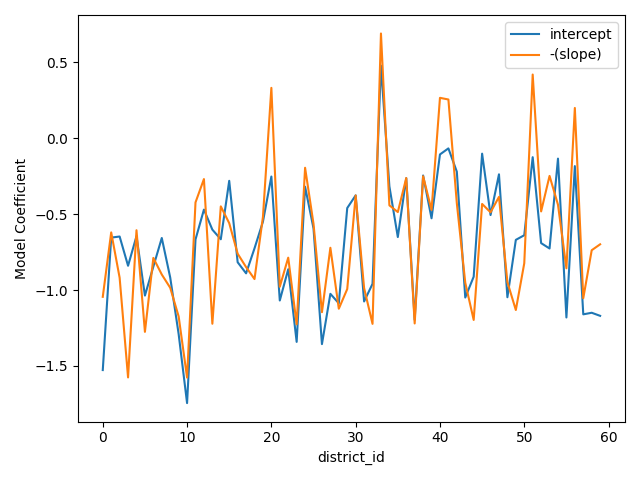

```python
mean_coeffs = trace_1_1.posterior.coeffs.mean(dim=('chain', 'draw')).values

fig, ax = plt.subplots(1,1)
fig.set_tight_layout(True)

ax.plot(range(num_districts), mean_coeffs[:,0], label='intercept')
ax.plot(range(num_districts), -mean_coeffs[:,1], label='-(slope)')
ax.set_xlabel('district_id')
ax.set_ylabel('Model Coefficient')
ax.legend(loc=0)
```

This looks as if 'slope = - intercept.'

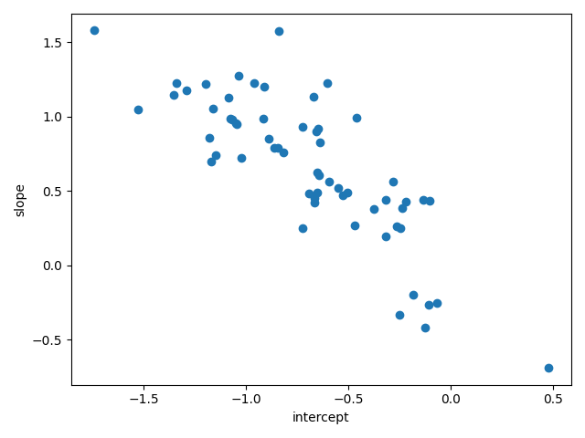

```python
fig, ax = plt.subplots(1,1)
fig.set_tight_layout(True)

ax.scatter(mean_coeffs[:,0], mean_coeffs[:,1])
ax.set_xlabel('intercept')
ax.set_ylabel('slope')
```

```python
with model_1_1:
     ppc_1_1 = pm.sample_posterior_predictive(trace_1_1, var_names=['coeffs', 'contraception'],
                                              random_seed=RANDOM_SEED)
```

100.00% [8000/8000 00:59<00:00]

```python
def sigmoid(x):
    return 1/(1+np.exp(-x))
```

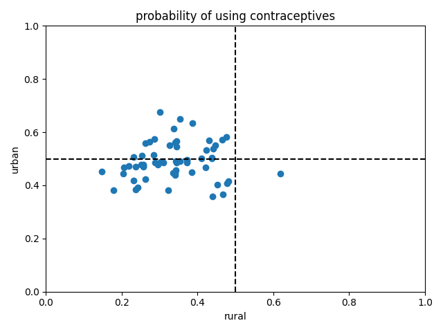

```python
fig, ax = plt.subplots(1,1)
fig.set_tight_layout(True)

# make predictions for urban and rural
mu_rural = ppc_1_1['coeffs'][:,:,0]
mu_urban = ppc_1_1['coeffs'][:,:,0] + ppc_1_1['coeffs'][:,:,1]*np.ones(ppc_1_1['coeffs'].shape[:2])

ax.scatter(sigmoid(mu_rural.mean(axis=0)), sigmoid(mu_urban.mean(axis=0)))
ax.set_xlim(0,1)
ax.set_ylim(0,1)
ax.axhline(0.5, ls='--', c='k')
ax.axvline(0.5, ls='--', c='k')
ax.set_xlabel('rural')
ax.set_ylabel('urban')
ax.set_title('probability of using contraceptives')
```

There is a big difference between urban and rural locations. We can reparametrize the model by using two intercepts, one for urban and one for rural instead of an intercept and a slope. The two intercepts then have basically no correlation.

```python
with pm.Model() as model_1_2:
    district_id = pm.Data('district_id', df['district_id'])
    urban = pm.Data('urban', df['urban'])
    coc_obs = pm.Data('contraception_obs', df['use.contraception'])

    a_bar = pm.Normal('a_bar', mu=0, sd=1)
    b_bar = pm.Normal('b_bar', mu=0, sd=0.5)

    sd_dist = pm.Exponential.dist(1.0) # Note the .dist to avoid creating a new variable
    chol, corr, sigmas = pm.LKJCholeskyCov('chol_cov', eta=2, n=2,
                                           sd_dist=sd_dist, compute_corr=True)
    coeffs = pm.MvNormal('coeffs', mu=[a_bar, b_bar], chol=chol, shape=(num_districts,2))

    p = pm.invlogit(coeffs[district_id,urban])
    coc = pm.Bernoulli('contraception', p, observed=coc_obs)

    trace_1_2 = pm.sample(2000, tune=2000, return_inferencedata=True, random_seed=RANDOM_SEED, chains=4,
                          target_accept=0.9)
```

```
Auto-assigning NUTS sampler...
Initializing NUTS using jitter+adapt_diag...
Multiprocess sampling (4 chains in 4 jobs)
NUTS: [coeffs, chol_cov, b_bar, a_bar]
```

100.00% [16000/16000 01:32<00:00 Sampling 4 chains, 0 divergences]

```
Sampling 4 chains for 2_000 tune and 2_000 draw iterations (8_000 + 8_000 draws total) took 93 seconds.
The number of effective samples is smaller than 10% for some parameters.
```

```python
az.summary(trace_1_2, var_names=['a_bar', 'b_bar', 'chol_cov_corr', 'chol_cov_stds'], round_to=2)
```

|  | mean | sd | hdi_3% | hdi_97% | mcse_mean | mcse_sd | ess_mean | ess_sd | ess_bulk | ess_tail | r_hat |
| --- | --- | --- | --- | --- | --- | --- | --- | --- | --- | --- | --- |
| a_bar | -0.71 | 0.11 | -0.92 | -0.52 | 0.00 | 0.0 | 5711.17 | 5588.66 | 5734.97 | 5638.98 | 1.0 |
| b_bar | 0.02 | 0.13 | -0.22 | 0.26 | 0.00 | 0.0 | 2708.93 | 2708.93 | 2709.89 | 3462.13 | 1.0 |
| chol_cov_corr[0,0] | 1.00 | 0.00 | 1.00 | 1.00 | 0.00 | 0.0 | 8000.00 | 8000.00 | 8000.00 | 8000.00 | NaN |
| chol_cov_corr[0,1] | -0.10 | 0.27 | -0.59 | 0.40 | 0.01 | 0.0 | 1757.05 | 1757.05 | 1762.57 | 3174.29 | 1.0 |
| chol_cov_corr[1,0] | -0.10 | 0.27 | -0.59 | 0.40 | 0.01 | 0.0 | 1757.05 | 1757.05 | 1762.57 | 3174.29 | 1.0 |
| chol_cov_corr[1,1] | 1.00 | 0.00 | 1.00 | 1.00 | 0.00 | 0.0 | 8000.00 | 8000.00 | 8511.40 | 8000.00 | 1.0 |
| chol_cov_stds[0] | 0.62 | 0.11 | 0.43 | 0.82 | 0.00 | 0.0 | 2556.51 | 2556.51 | 2549.00 | 4096.68 | 1.0 |
| chol_cov_stds[1] | 0.51 | 0.15 | 0.25 | 0.81 | 0.01 | 0.0 | 686.37 | 686.37 | 647.09 | 926.27 | 1.0 |

```python
summary = az.summary(trace_1_2, round_to=2)
```

```python
summary[summary.ess_tail < 2000]
```

|  | mean | sd | hdi_3% | hdi_97% | mcse_mean | mcse_sd | ess_mean | ess_sd | ess_bulk | ess_tail | r_hat |
| --- | --- | --- | --- | --- | --- | --- | --- | --- | --- | --- | --- |
| chol_cov[2] | 0.49 | 0.15 | 0.21 | 0.75 | 0.01 | 0.0 | 688.00 | 688.00 | 642.91 | 927.99 | 1.0 |
| chol_cov_stds[1] | 0.51 | 0.15 | 0.25 | 0.81 | 0.01 | 0.0 | 686.37 | 686.37 | 647.09 | 926.27 | 1.0 |

# 2 Effect of Age and Children

```python
df['age_sd'] = (df['age.centered'] - df['age.centered'].mean()) / df['age.centered'].std()
df['children_sd'] = (df['living.children'] - df['living.children'].mean()) / df['living.children'].std()
```

## Model Using Age Only

```python
with pm.Model() as model_2_1:
    district_id = pm.Data('district_id', df['district_id'])
    urban = pm.Data('urban', df['urban'])
    coc_obs = pm.Data('contraception_obs', df['use.contraception'])
    age = pm.Data('age', df['age_sd'])

    a_bar = pm.Normal('a_bar', mu=0, sd=1)
    b_bar = pm.Normal('b_bar', mu=0, sd=0.5)

    sd_dist = pm.Exponential.dist(1.0) # Note the .dist to avoid creating a new variable
    chol, corr, sigmas = pm.LKJCholeskyCov('chol_cov', eta=2, n=2,
                                           sd_dist=sd_dist, compute_corr=True)
    coeffs = pm.MvNormal('coeffs', mu=[a_bar, b_bar], chol=chol, shape=(num_districts,2))

    bA = pm.Normal('bA', mu=0, sd=0.5)

    p = pm.invlogit(coeffs[district_id,0] + coeffs[district_id,1]*urban + bA*age)
    coc = pm.Bernoulli('contraception', p, observed=coc_obs)

    trace_2_1 = pm.sample(2000, tune=2000, return_inferencedata=True, random_seed=RANDOM_SEED, chains=4,
                          target_accept=0.9)
```

```
Auto-assigning NUTS sampler...
Initializing NUTS using jitter+adapt_diag...
Multiprocess sampling (4 chains in 4 jobs)
NUTS: [bA, coeffs, chol_cov, b_bar, a_bar]
```

100.00% [16000/16000 02:35<00:00 Sampling 4 chains, 3 divergences]

```
Sampling 4 chains for 2_000 tune and 2_000 draw iterations (8_000 + 8_000 draws total) took 155 seconds.
There was 1 divergence after tuning. Increase `target_accept` or reparameterize.
There was 1 divergence after tuning. Increase `target_accept` or reparameterize.
There was 1 divergence after tuning. Increase `target_accept` or reparameterize.
The number of effective samples is smaller than 25% for some parameters.
```

```python
az.summary(trace_2_1, var_names=['a_bar', 'b_bar', 'bA', 'chol_cov_corr', 'chol_cov_stds'], round_to=2)
```

|  | mean | sd | hdi_3% | hdi_97% | mcse_mean | mcse_sd | ess_mean | ess_sd | ess_bulk | ess_tail | r_hat |
| --- | --- | --- | --- | --- | --- | --- | --- | --- | --- | --- | --- |
| a_bar | -0.69 | 0.10 | -0.87 | -0.50 | 0.00 | 0.0 | 6922.82 | 6922.82 | 6919.80 | 6436.97 | 1.00 |
| b_bar | 0.64 | 0.16 | 0.31 | 0.92 | 0.00 | 0.0 | 5204.10 | 5204.10 | 5199.69 | 5845.17 | 1.00 |
| bA | 0.08 | 0.05 | -0.01 | 0.17 | 0.00 | 0.0 | 12729.32 | 8284.15 | 12734.07 | 5517.07 | 1.00 |
| chol_cov_corr[0,0] | 1.00 | 0.00 | 1.00 | 1.00 | 0.00 | 0.0 | 8000.00 | 8000.00 | 8000.00 | 8000.00 | NaN |
| chol_cov_corr[0,1] | -0.65 | 0.17 | -0.92 | -0.32 | 0.00 | 0.0 | 1367.84 | 1367.84 | 1328.87 | 1961.64 | 1.00 |
| chol_cov_corr[1,0] | -0.65 | 0.17 | -0.92 | -0.32 | 0.00 | 0.0 | 1367.84 | 1367.84 | 1328.87 | 1961.64 | 1.00 |
| chol_cov_corr[1,1] | 1.00 | 0.00 | 1.00 | 1.00 | 0.00 | 0.0 | 8000.00 | 8000.00 | 7735.14 | 7864.77 | 1.00 |
| chol_cov_stds[0] | 0.58 | 0.10 | 0.40 | 0.76 | 0.00 | 0.0 | 2634.27 | 2634.27 | 2559.00 | 3876.43 | 1.00 |
| chol_cov_stds[1] | 0.79 | 0.20 | 0.39 | 1.15 | 0.01 | 0.0 | 1141.78 | 1141.78 | 1109.13 | 1381.28 | 1.01 |

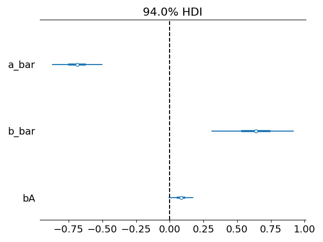

```python
fig, ax = plt.subplots(1,1)
fig.set_tight_layout(True)
az.plot_forest(trace_2_1, var_names=['a_bar', 'b_bar', 'bA'], combined=True, ax=ax)
ax.axvline(0, ls='--', c='k')
```

The total effect of age is small, but quite likely positive.

## Model Using Age and Children

```python
with pm.Model() as model_2_2:
    district_id = pm.Data('district_id', df['district_id'])
    urban = pm.Data('urban', df['urban'])
    coc_obs = pm.Data('contraception_obs', df['use.contraception'])
    age = pm.Data('age', df['age_sd'])
    children = pm.Data('children', df['children_sd'])

    a_bar = pm.Normal('a_bar', mu=0, sd=1)
    b_bar = pm.Normal('b_bar', mu=0, sd=0.5)

    sd_dist = pm.Exponential.dist(1.0) # Note the .dist to avoid creating a new variable
    chol, corr, sigmas = pm.LKJCholeskyCov('chol_cov', eta=2, n=2,
                                           sd_dist=sd_dist, compute_corr=True)
    coeffs = pm.MvNormal('coeffs', mu=[a_bar, b_bar], chol=chol, shape=(num_districts,2))

    bA = pm.Normal('bA', mu=0, sd=0.5)
    bC = pm.Normal('bC', mu=0, sd=0.5)

    p = pm.invlogit(coeffs[district_id,0] + coeffs[district_id,1]*urban + bA*age + bC*children)
    coc = pm.Bernoulli('contraception', p, observed=coc_obs)

    trace_2_2 = pm.sample(2000, tune=2000, return_inferencedata=True, random_seed=RANDOM_SEED, chains=4,
                          target_accept=0.9)
```

```
Auto-assigning NUTS sampler...
Initializing NUTS using jitter+adapt_diag...
Multiprocess sampling (4 chains in 4 jobs)
NUTS: [bC, bA, coeffs, chol_cov, b_bar, a_bar]
```

100.00% [16000/16000 02:44<00:00 Sampling 4 chains, 5 divergences]

```
Sampling 4 chains for 2_000 tune and 2_000 draw iterations (8_000 + 8_000 draws total) took 165 seconds.
There were 2 divergences after tuning. Increase `target_accept` or reparameterize.
There was 1 divergence after tuning. Increase `target_accept` or reparameterize.
There were 2 divergences after tuning. Increase `target_accept` or reparameterize.
The number of effective samples is smaller than 25% for some parameters.
```

```python
az.summary(trace_2_2, var_names=['a_bar', 'b_bar', 'bA', 'bC', 'chol_cov_corr', 'chol_cov_stds'], round_to=2)
```

|  | mean | sd | hdi_3% | hdi_97% | mcse_mean | mcse_sd | ess_mean | ess_sd | ess_bulk | ess_tail | r_hat |
| --- | --- | --- | --- | --- | --- | --- | --- | --- | --- | --- | --- |
| a_bar | -0.72 | 0.10 | -0.91 | -0.52 | 0.00 | 0.0 | 6972.40 | 6866.39 | 6994.57 | 5831.82 | 1.0 |
| b_bar | 0.69 | 0.16 | 0.40 | 1.01 | 0.00 | 0.0 | 4832.22 | 4832.22 | 4810.65 | 5491.03 | 1.0 |
| bA | -0.26 | 0.07 | -0.40 | -0.13 | 0.00 | 0.0 | 10089.07 | 9561.15 | 10055.79 | 5743.17 | 1.0 |
| bC | 0.51 | 0.07 | 0.38 | 0.64 | 0.00 | 0.0 | 9722.30 | 9722.30 | 9701.20 | 6249.50 | 1.0 |
| chol_cov_corr[0,0] | 1.00 | 0.00 | 1.00 | 1.00 | 0.00 | 0.0 | 8000.00 | 8000.00 | 8000.00 | 8000.00 | NaN |
| chol_cov_corr[0,1] | -0.63 | 0.17 | -0.90 | -0.30 | 0.00 | 0.0 | 2009.24 | 2009.24 | 1967.86 | 3298.63 | 1.0 |
| chol_cov_corr[1,0] | -0.63 | 0.17 | -0.90 | -0.30 | 0.00 | 0.0 | 2009.24 | 2009.24 | 1967.86 | 3298.63 | 1.0 |
| chol_cov_corr[1,1] | 1.00 | 0.00 | 1.00 | 1.00 | 0.00 | 0.0 | 8000.00 | 8000.00 | 8178.73 | 7998.51 | 1.0 |
| chol_cov_stds[0] | 0.61 | 0.10 | 0.42 | 0.80 | 0.00 | 0.0 | 2703.11 | 2703.11 | 2639.61 | 3631.87 | 1.0 |
| chol_cov_stds[1] | 0.76 | 0.20 | 0.38 | 1.15 | 0.01 | 0.0 | 955.64 | 955.64 | 923.26 | 959.84 | 1.0 |

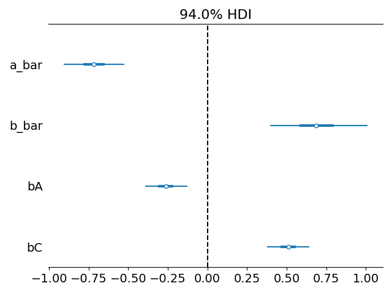

```python
fig, ax = plt.subplots(1,1)
fig.set_tight_layout(True)
az.plot_forest(trace_2_2, var_names=['a_bar', 'b_bar', 'bA', 'bC'], combined=True, ax=ax)
ax.axvline(0, ls='--', c='k')
```

The effect of age is larger and it changed sign. The effect of children is large and postive. This makes sense, because families with a lot of children may not want more children. As for age, it is possible that older people are more conservative and therefore opposed to contraception. In the previous model the effect of age was probably positive, because it incorporated the effect of children.

# 3 Include Children as an Ordered Variable

```python
# delta = pm.Dirichlet('delta', np.full(NUM_EDU_CATEGORIES-1,2))
#     delta_j = pm.math.concatenate((tt.zeros(1), delta))
#     delta_j_cumsum = tt.cumsum(delta_j)
```

```python
MAX_CHILDREN = df['living.children'].max()
MAX_CHILDREN
```

```
4
```

```python
df['living.children'].value_counts()
```

```
4    743
1    530
2    356
3    305
Name: living.children, dtype: int64
```

Note the smallest number of children is 1. This means that MAX_CHILDREN is equal to the number of possible categories: 1, 2, 3, 4

```python
with pm.Model() as model_3_1:
    district_id = pm.Data('district_id', df['district_id'])
    urban = pm.Data('urban', df['urban'])
    coc_obs = pm.Data('contraception_obs', df['use.contraception'])
    age = pm.Data('age', df['age_sd'])
    children = pm.Data('children', df['living.children'])

    a_bar = pm.Normal('a_bar', mu=0, sd=1)
    b_bar = pm.Normal('b_bar', mu=0, sd=0.5)

    sd_dist = pm.Exponential.dist(1.0) # Note the .dist to avoid creating a new variable
    chol, corr, sigmas = pm.LKJCholeskyCov('chol_cov', eta=2, n=2,
                                           sd_dist=sd_dist, compute_corr=True)
    coeffs = pm.MvNormal('coeffs', mu=[a_bar, b_bar], chol=chol, shape=(num_districts,2))

    bA = pm.Normal('bA', mu=0, sd=0.5)

    # treat children variable as ordered
    delta = pm.Dirichlet('delta', np.full(MAX_CHILDREN-1,2))
    delta_j = pm.math.concatenate((tt.zeros(1), delta))
    delta_j_cumsum = tt.cumsum(delta_j)

    bC = pm.Normal('bC', mu=0, sd=0.5)

    p = pm.invlogit(coeffs[district_id,0] + coeffs[district_id,1]*urban + bA*age +\
                    bC*delta_j_cumsum[children -1]) # note the -1, because children starts at 1
    coc = pm.Bernoulli('contraception', p, observed=coc_obs)

    trace_3_1 = pm.sample(2000, tune=2000, return_inferencedata=True, random_seed=RANDOM_SEED, chains=4,
                          target_accept=0.9)
```

```
Auto-assigning NUTS sampler...
Initializing NUTS using jitter+adapt_diag...
Multiprocess sampling (4 chains in 4 jobs)
NUTS: [bC, delta, bA, coeffs, chol_cov, b_bar, a_bar]
```

100.00% [16000/16000 03:13<00:00 Sampling 4 chains, 0 divergences]

```
Sampling 4 chains for 2_000 tune and 2_000 draw iterations (8_000 + 8_000 draws total) took 194 seconds.
The number of effective samples is smaller than 10% for some parameters.
```

```python
az.summary(trace_3_1, var_names=['a_bar', 'b_bar', 'bA', 'bC', 'delta', 'chol_cov_corr', 'chol_cov_stds'],
           round_to=2)
```

|  | mean | sd | hdi_3% | hdi_97% | mcse_mean | mcse_sd | ess_mean | ess_sd | ess_bulk | ess_tail | r_hat |
| --- | --- | --- | --- | --- | --- | --- | --- | --- | --- | --- | --- |
| a_bar | -1.56 | 0.14 | -1.83 | -1.29 | 0.00 | 0.00 | 2687.06 | 2687.06 | 2684.50 | 4708.41 | 1.0 |
| b_bar | 0.69 | 0.16 | 0.39 | 1.00 | 0.00 | 0.00 | 4931.28 | 4931.28 | 4917.85 | 5828.27 | 1.0 |
| bA | -0.23 | 0.06 | -0.35 | -0.11 | 0.00 | 0.00 | 5667.04 | 5667.04 | 5660.42 | 5805.01 | 1.0 |
| bC | 1.27 | 0.15 | 0.98 | 1.54 | 0.00 | 0.00 | 2797.23 | 2797.23 | 2800.19 | 4689.24 | 1.0 |
| delta[0] | 0.74 | 0.08 | 0.58 | 0.89 | 0.00 | 0.00 | 10889.14 | 10494.45 | 10570.07 | 5075.99 | 1.0 |
| delta[1] | 0.16 | 0.08 | 0.02 | 0.31 | 0.00 | 0.00 | 10610.84 | 9388.80 | 10136.05 | 5379.16 | 1.0 |
| delta[2] | 0.10 | 0.05 | 0.01 | 0.19 | 0.00 | 0.00 | 10043.60 | 8324.13 | 9629.17 | 4795.47 | 1.0 |
| chol_cov_corr[0,0] | 1.00 | 0.00 | 1.00 | 1.00 | 0.00 | 0.00 | 8000.00 | 8000.00 | 8000.00 | 8000.00 | NaN |
| chol_cov_corr[0,1] | -0.63 | 0.18 | -0.91 | -0.31 | 0.01 | 0.00 | 1156.59 | 1156.59 | 1284.92 | 1917.29 | 1.0 |
| chol_cov_corr[1,0] | -0.63 | 0.18 | -0.91 | -0.31 | 0.01 | 0.00 | 1156.59 | 1156.59 | 1284.92 | 1917.29 | 1.0 |
| chol_cov_corr[1,1] | 1.00 | 0.00 | 1.00 | 1.00 | 0.00 | 0.00 | 8000.00 | 8000.00 | 7690.33 | 7607.78 | 1.0 |
| chol_cov_stds[0] | 0.59 | 0.10 | 0.41 | 0.79 | 0.00 | 0.00 | 1453.74 | 1453.74 | 1428.64 | 2623.71 | 1.0 |
| chol_cov_stds[1] | 0.75 | 0.21 | 0.33 | 1.14 | 0.01 | 0.01 | 517.75 | 517.75 | 501.47 | 447.59 | 1.0 |

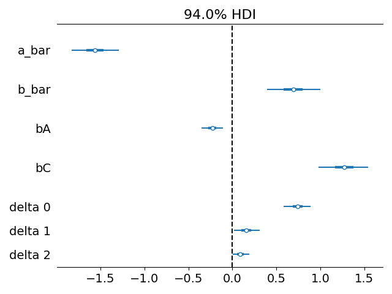

```python
fig, ax = plt.subplots(1,1)
fig.set_tight_layout(True)
az.plot_forest(trace_3_1, var_names=['a_bar', 'b_bar', 'bA', 'bC', 'delta'], combined=True, ax=ax)
ax.axvline(0, ls='--', c='k')
```

Note that `delta[0]` is corresponds to the change of going from 1 child to 2 children and is larger than `delta[1]` and `delta[2]`. This means that having a second child has the biggest impact on the use of contraception.

Note also that `bC` is larger than for the previous model. This makes sense, because a large `bC` value in the previous model would mean that having 4 children has a very large effect, whereas when children is included as an ordered variable the effect of having a 4th child can be rather small compared to the effect of having a second or third child.